# Final project

## Overivew

In this final project, your team will analyze the relationship between three demographic variables and the congressional vote in the 1992 and 2016 elections in one of the four major census regions. Those three variables will be percentage of the population NOT classified as white, non-Hispanic, percentage with a bachelor’s degree or higher, and median household income. In each time period, the district value for these variables is the median tract value from the 1990 decennial census and 2011-15 ACS.

Within your group, each person will choose one variable to analyze. You’ll look at the statistical and spatial distribution of this variable by state and use regression to analyze the association between it and the House election in each year.

Together, your group will also create a “first difference” model for states in your region, understanding how changes in the district demographics were associated with changes in the states efficiency gap.

```r
library(tidyverse)
library(sf)

proj_region="Midwest Region"

district_data<-read_csv("districts_data_all.csv") %>%
  mutate(year=as.character(year))
```

This shape file includes political districts in both 1992 and 2016 (1990 and 2015 in the year field), a variety of demographic variables, and results for the U.S. House elections in both years. There’s also some dummy variables for elections that were uncontested (uncon_r and uncon_d), elections with no vote totals (missing), and states with 2 or less districts (dist_omit).

The three demographic variables you’re interested in are % not classifed as white, non-hispanic (nonwht_pct), median household income (medhhinc), and % with a BA degree or higher (badeg_pct).

Before plotting these data, we will remove all districts with missing data, which have -99 as the vote total. We will also top and bottom code uncontested races, using the figure from Stephanopoulis and McGhee (2015) of 66% of the vote being Democractic in uncontested Democratic races and 36% of the vote being Democratic in uncontested Republican races.

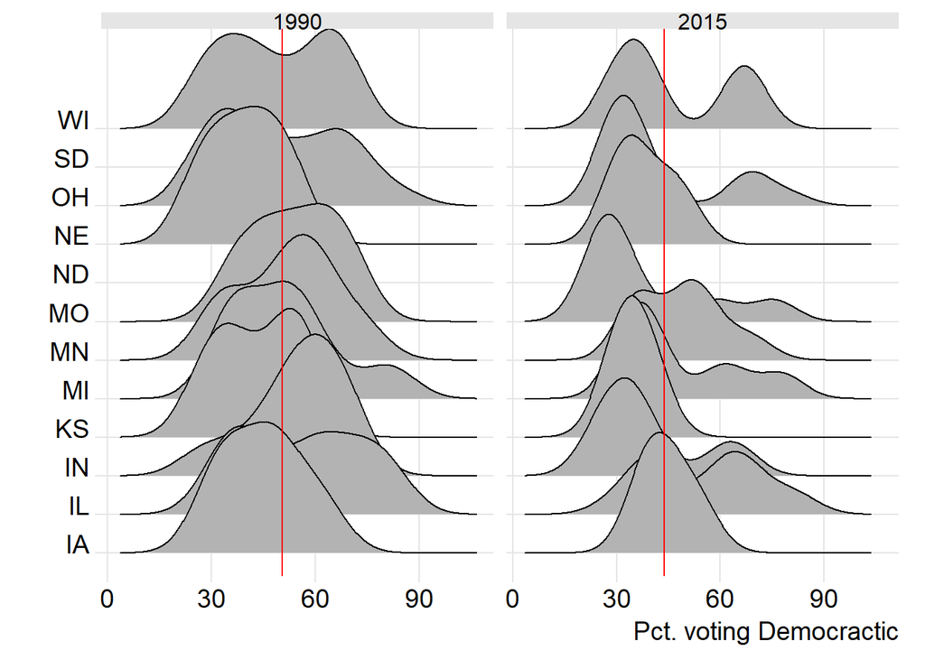

```r
library(ggridges)
districts_select<-district_data %>%
  filter(Region==proj_region) %>%
  group_by(year) %>%
  mutate(median_dem=mean(pct_dem),
         pct_dem_adj=ifelse(uncontest_r==1,66,ifelse(uncontest_d==1,36,pct_dem))) %>%
  filter(total_vote!=-99)

ggplot(districts_select,aes(x=pct_dem_adj,y=st_abbr))+
  geom_density_ridges(scale=3)+
  theme_ridges()+
  geom_vline(aes(xintercept = median_dem),col="red")+
  facet_wrap(~year)+
  xlab("Pct. voting Democractic")+
  ylab("")
```

You can also map the data by year using tmap, also filtering out districts with missing data. We will add in state boundaries as well, removing the border lines for individual districts.

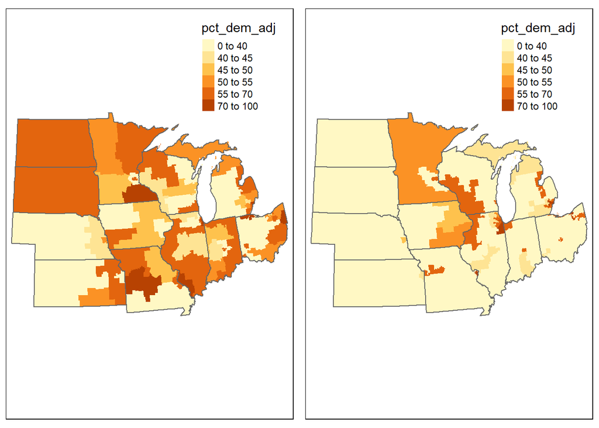

```r
districts_1990<-districts_join %>% filter(year=="1990" & Region==proj_region)
districts_2015<-districts_join %>% filter(year=="2015" & Region==proj_region)

map1<-tm_shape(districts_1990,projection="2163") +
  tm_polygons("pct_dem_adj", breaks=c(0,40,45,50,55,70,100),border.alpha=0)+
  tm_shape(states) + tm_borders()

map2<-tm_shape(districts_2015,projection="2163") +
  tm_polygons("pct_dem_adj", breaks=c(0,40,45,50,55,70,100),border.alpha=0)+
  tm_shape(states) + tm_borders()

tmap_arrange(map1,map2)
```

```r
model1990<-lm(pct_dem_adj~hisp_pct,data=districts_1990)
summary(model1990)
```

```
##
## Call:
## lm(formula = pct_dem_adj ~ hisp_pct, data = districts_1990)
##
## Residuals:
##     Min      1Q  Median      3Q     Max
## -24.928 -13.298   0.181  11.089  32.969
##
## Coefficients:
##             Estimate Std. Error t value Pr(>|t|)
## (Intercept)  50.6757     1.5862  31.948   <2e-16 ***
## hisp_pct      0.6480     0.3469   1.868   0.0646 .
## ---
## Signif. codes:  0 '***' 0.001 '**' 0.01 '*' 0.05 '.' 0.1 ' ' 1
##
## Residual standard error: 15.09 on 103 degrees of freedom
## Multiple R-squared:  0.03278,    Adjusted R-squared:  0.02339
## F-statistic:  3.49 on 1 and 103 DF,  p-value: 0.06457
```

```r
model2015<-lm(pct_dem_adj~hisp_pct,data=districts_2015)
summary(model2015)
```

```
##
## Call:
## lm(formula = pct_dem_adj ~ hisp_pct, data = districts_2015)
##
## Residuals:
##     Min      1Q  Median      3Q     Max
## -21.238 -11.800  -6.015  13.040  37.477
##
## Coefficients:
##             Estimate Std. Error t value Pr(>|t|)
## (Intercept)  42.5517     1.9109  22.268  < 2e-16 ***
## hisp_pct      0.5324     0.1997   2.666  0.00907 **
## ---
## Signif. codes:  0 '***' 0.001 '**' 0.01 '*' 0.05 '.' 0.1 ' ' 1
##
## Residual standard error: 15.85 on 92 degrees of freedom
## Multiple R-squared:  0.07171,    Adjusted R-squared:  0.06162
## F-statistic: 7.107 on 1 and 92 DF,  p-value: 0.009068
```

We can show the model results more concisely in a stargazer table. (Install the stargazer package first.)

```r
stargazer::stargazer(model1990,model2015, type = "html",
 title = "Model results with stargazer",
 column.labels = c("1992 election", "2016 election"))
```

**Model results with stargazer**

|  | *Dependent variable:* |  |
| --- | --- | --- |
|  | pct_dem_adj |  |
|  | 1992 election | 2016 election |
|  | (1) | (2) |
| hisp_pct | 0.648* | 0.532*** |
|  | (0.347) | (0.200) |
| Constant | 50.676*** | 42.552*** |
|  | (1.586) | (1.911) |
| Observations | 105 | 94 |
| R<sup>2</sup> | 0.033 | 0.072 |
| Adjusted R<sup>2</sup> | 0.023 | 0.062 |
| Residual Std. Error | 15.092 (df = 103) | 15.852 (df = 92) |
| F Statistic | 3.490* (df = 1; 103) | 7.107*** (df = 1; 92) |
| *Note:* | p<0.1; p<0.05; p<0.01 |  |

We can also plot each model with ggplot:

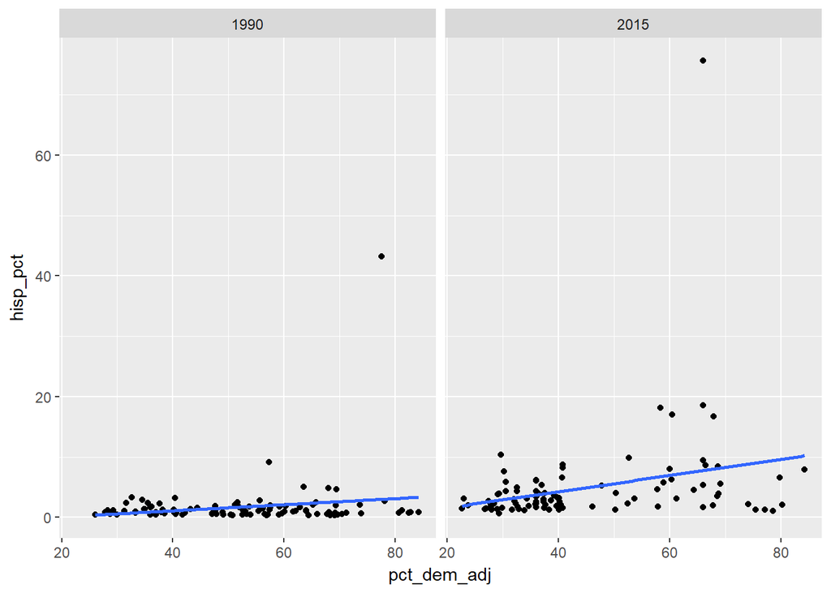

```r
ggplot(districts_select,aes(x=pct_dem_adj,y=hisp_pct)) +
  geom_point()+
  geom_smooth(method = "lm", se = FALSE)+
  facet_wrap(~year)
```

Lastly, we can map out the location of residuals to better understand the model results. To help interpret the residual values, we will use the scale function to convert them to a z score.

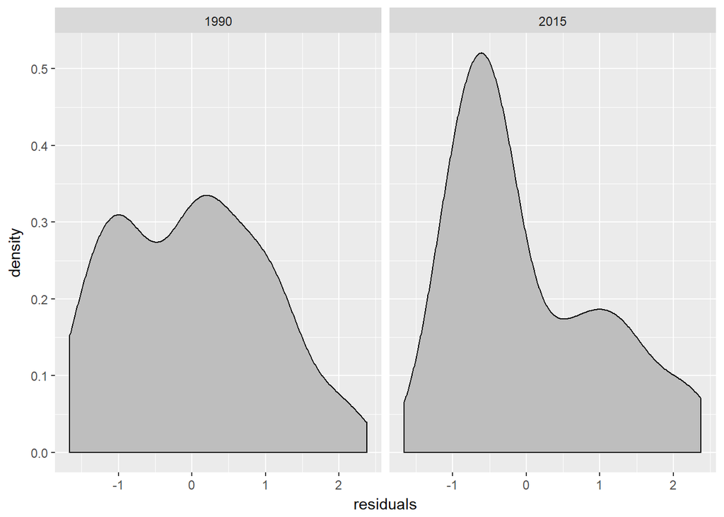

```r
districts_1990$residuals<-as.numeric(scale(residuals(model1990)))
districts_2015$residuals<-as.numeric(scale(residuals(model2015)))
districts_combine<-rbind(districts_1990,districts_2015)

ggplot(districts_combine,aes(x=residuals))+
  geom_density(fill="grey")+
  facet_wrap(~year)
```

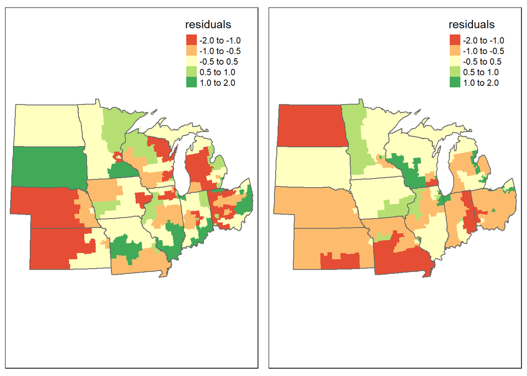

```r
map3<-tm_shape(districts_1990,projection="2163") +
  tm_polygons("residuals", breaks=c(-2,-1,-0.5,0.5,1,2),border.alpha=0)+
  tm_shape(states) + tm_borders()

map4<-tm_shape(districts_2015,projection="2163") +
  tm_polygons("residuals", breaks=c(-2,-1,-0.5,0.5,1,2),border.alpha=0)+
  tm_shape(states) + tm_borders()

tmap_arrange(map3,map4)
```

Lastly, save the spatial data files for 1990 and 2015 to a shapefile using st_write. Load these files into Geoda and measure the spatial autocorrelation of the residuals using the Moran’s I statistic.

Questions:

1. Ridge plot and analysis
2. Map and analysis
3. Models and analysis
4. Diagnostics with residuals

Group question

1. State level mean and efficency gap: map/plot and run model
2. First differences model: map and run model